# HawkMom

Edgardo L. Rosado Ramos

2025-10-12

# 3. Data Import

Now, we will import the Mothur output files: the shared file (OTU table), the taxonomy file, and the design file (metadata). Make sure these files are in the same directory as this Rmd file, or provide the full path to them.

```r
#make phyloseq object
library(phyloseq)
library(microbiome)  # Optional, for further analysis
library(tidyverse)   # For data manipulation

otu_file <- "final.opti_mcc.0.03.subsample.shared"
tax_file <- "final.opti_mcc.0.03.cons.taxonomy"
metadata_file <- "hawkm.design"

# Read OTU table
otu_raw <- read.table("final.opti_mcc.0.03.subsample.shared", header = TRUE, sep = "\t", stringsAsFactors = FALSE)

# Remove metadata columns
otu_mat <- otu_raw[, -(1:3)]  # removes label, Group, numOtus

# Set rownames as sample IDs
rownames(otu_mat) <- otu_raw$Group

# Transpose so OTUs are rows
otu_mat <- t(otu_mat)

# Create phyloseq OTU table
otu_tab <- otu_table(otu_mat, taxa_are_rows = TRUE)
```

```r
# --- 1. Read the taxonomy file ---
tax_raw <- read.table("final.opti_mcc.0.03.cons.taxonomy",
                      sep = "\t", header = TRUE, stringsAsFactors = FALSE, quote = "")

# --- 2. Extract taxonomy strings and OTU IDs ---
taxonomy_strings <- tax_raw$Taxonomy
names(taxonomy_strings) <- tax_raw$OTU

# --- 3. Split taxonomy strings by ';' and clean ---
taxonomy_clean <- strsplit(taxonomy_strings, ";")

taxonomy_clean <- lapply(taxonomy_clean, function(x) {
  x <- x[nchar(x) > 0]                # Remove empty strings
  x <- gsub("\\(.*?\\)", "", x)       # Remove confidence scores in parentheses
  x <- gsub('\\"', '', x)              # Remove escaped quotes
  trimws(x)                           # Trim whitespace
})

# --- 4. Pad each taxonomy vector to length 7 (Kingdom to Species) ---
max_ranks <- 7
taxonomy_mat <- do.call(rbind, lapply(taxonomy_clean, function(x) {
  length(x) <- max_ranks  # pad with NAs if needed
  x
}))

# --- 5. Assign column and row names ---
colnames(taxonomy_mat) <- c("Kingdom", "Phylum", "Class", "Order", "Family", "Genus", "Species")
rownames(taxonomy_mat) <- names(taxonomy_strings)

# --- 6. Create tax_table object for phyloseq ---
tax_tab <- tax_table(as.matrix(taxonomy_mat))

# --- Optional: Check the result ---
head(tax_tab)
```

```
## Taxonomy Table:     [6 taxa by 7 taxonomic ranks]:
##           Kingdom    Phylum                  Class
## Otu000001 "Bacteria" "Proteobacteria"        "Epsilonproteobacteria"
## Otu000002 "Bacteria" "Proteobacteria"        "Gammaproteobacteria"
## Otu000003 "Bacteria" "Bacteria_unclassified" "Bacteria_unclassified"
## Otu000004 "Bacteria" "Chlamydiae"            "Chlamydiae"
## Otu000005 "Bacteria" "Bacteroidetes"         "Bacteroidetes_unclassified"
## Otu000006 "Bacteria" "Bacteria_unclassified" "Bacteria_unclassified"
##           Order                        Family
## Otu000001 "Campylobacterales"          "Helicobacteraceae"
## Otu000002 "Pseudomonadales"            "Moraxellaceae"
## Otu000003 "Bacteria_unclassified"      "Bacteria_unclassified"
## Otu000004 "Chlamydiales"               "Chlamydiaceae"
## Otu000005 "Bacteroidetes_unclassified" "Bacteroidetes_unclassified"
## Otu000006 "Bacteria_unclassified"      "Bacteria_unclassified"
##           Genus                        Species
## Otu000001 "Helicobacter"               NA
## Otu000002 "Acinetobacter"              NA
## Otu000003 "Bacteria_unclassified"      NA
## Otu000004 "Chlamydophila"              NA
## Otu000005 "Bacteroidetes_unclassified" NA
## Otu000006 "Bacteria_unclassified"      NA
```

```r
# Read design file (skip header line)
metadata <- read.table("hawkm.design", header = FALSE, skip = 1, stringsAsFactors = FALSE)

# Rename columns
colnames(metadata) <- c("SampleID", "SampleType")

# Set rownames
rownames(metadata) <- metadata$SampleID
metadata$SampleID <- NULL

# Create sample_data object
sample_data_obj <- sample_data(metadata)
```

```r
physeq <- phyloseq(otu_tab, tax_tab, sample_data_obj)
physeq
```

```
## phyloseq-class experiment-level object
## otu_table()   OTU Table:         [ 18883 taxa and 42 samples ]
## sample_data() Sample Data:       [ 42 samples by 1 sample variables ]
## tax_table()   Taxonomy Table:    [ 18883 taxa by 7 taxonomic ranks ]
```

```r
physeq_final <- physeq
```

# 4. Data Pre-processing

Before analysis, it’s good practice to filter out the control samples for the main biological comparisons. We will create a separate phyloseq object without the control samples for diversity analysis.

```r
# Remove control samples for biological comparisons
phyloseq_nocontrol <- subset_samples(physeq_final, SampleType != "Control")

# We can also remove taxa that are not present in any of the remaining samples
phyloseq_nocontrol <- prune_taxa(taxa_sums(phyloseq_nocontrol) > 0, phyloseq_nocontrol)

# Inspect the new phyloseq object
print(phyloseq_nocontrol)
```

```
## phyloseq-class experiment-level object
## otu_table()   OTU Table:         [ 12966 taxa and 28 samples ]
## sample_data() Sample Data:       [ 28 samples by 1 sample variables ]
## tax_table()   Taxonomy Table:    [ 12966 taxa by 7 taxonomic ranks ]
```

# 5. Alpha Diversity

Alpha diversity refers to the diversity within a single sample. We will calculate several metrics (Observed OTUs, Shannon, and Simpson) and compare them between the Buccal and Cloaca sample types.

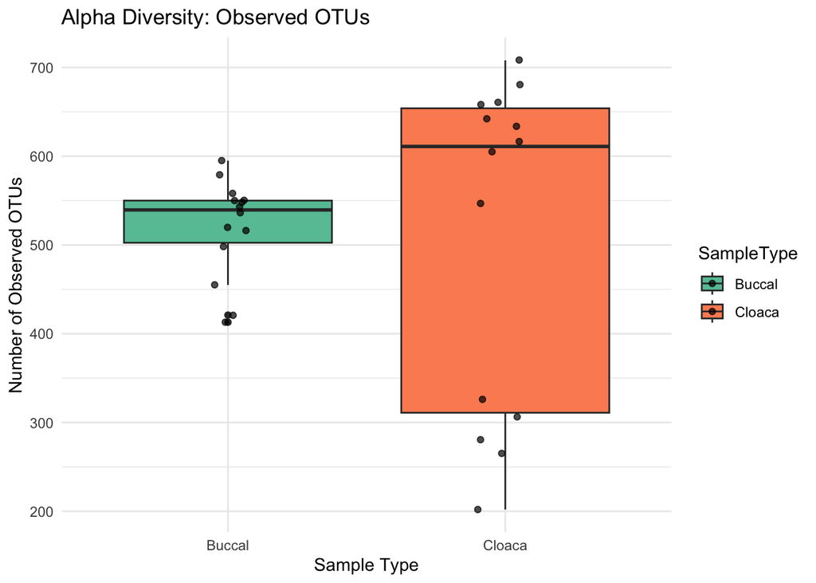

```r
# Calculate alpha diversity metrics using the 'phyloseq_nocontrol' object
alpha_div <- estimate_richness(phyloseq_nocontrol,
                               measures = c("Observed", "Shannon", "Simpson"))

# Add the sample type information from the correct phyloseq object
alpha_div$SampleType <- sample_data(phyloseq_nocontrol)$SampleType

# Plot the Observed OTUs
ggplot(alpha_div, aes(x = SampleType, y = Observed, fill = SampleType)) +
  geom_boxplot() +
  geom_jitter(width = 0.1, alpha = 0.7) +
  labs(title = "Alpha Diversity: Observed OTUs",
       x = "Sample Type",
       y = "Number of Observed OTUs") +
  theme_minimal() +
  scale_fill_brewer(palette = "Set2")
```

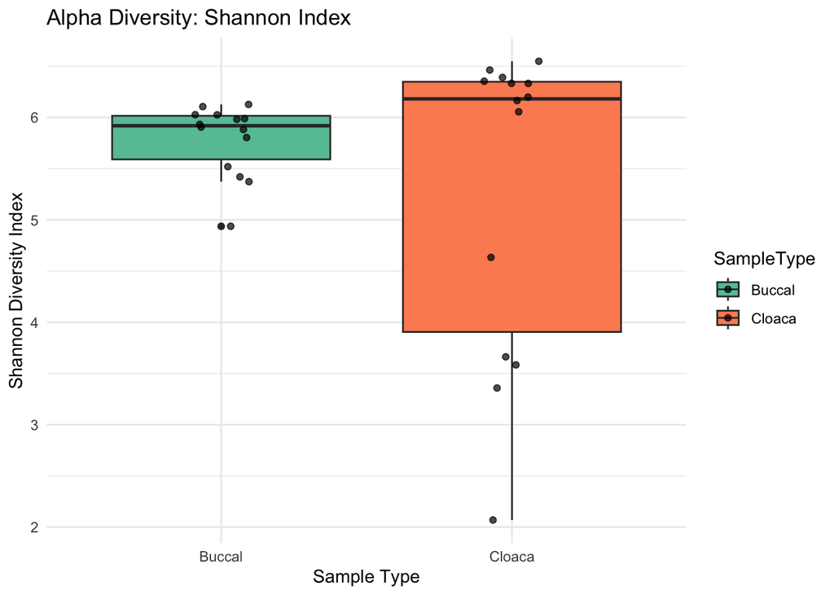

```r
# Plot the Shannon Diversity
ggplot(alpha_div, aes(x = SampleType, y = Shannon, fill = SampleType)) +
  geom_boxplot() +
  geom_jitter(width = 0.1, alpha = 0.7) +
  labs(title = "Alpha Diversity: Shannon Index",
       x = "Sample Type",
       y = "Shannon Diversity Index") +
  theme_minimal() +
  scale_fill_brewer(palette = "Set2")
```

```r
# --- Statistical Test ---
# This part was already correct as it uses the 'alpha_div' data frame
shannon_test <- wilcox.test(Shannon ~ SampleType, data = alpha_div)
cat("\nWilcoxon test for Shannon diversity:\n")
```

```
##
## Wilcoxon test for Shannon diversity:
```

```r
print(shannon_test)
```

```
##
##  Wilcoxon rank sum exact test
##
## data:  Shannon by SampleType
## W = 72, p-value = 0.2456
## alternative hypothesis: true location shift is not equal to 0
```

The plots above show the distribution of alpha diversity for Buccal and Cloaca samples. The Wilcoxon test helps determine if the observed differences in Shannon diversity are statistically significant.

# 7. Taxonomic Composition

Finally, let’s visualize the taxonomic breakdown of our samples to see which bacterial phyla are most abundant.

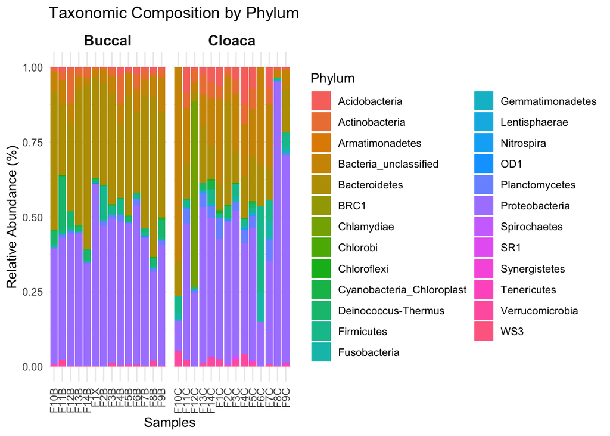

```r
# 1. Start with our clean, no-controls phyloseq object
#    Agglomerate the data at the "Phylum" level.
phylum_data <- tax_glom(phyloseq_nocontrol, taxrank = "Phylum", NArm = FALSE)

# 2. Transform the counts to relative abundance for accurate comparison
phylum_rel_abund <- transform_sample_counts(phylum_data, function(x) x / sum(x))

# 3. Create the bar plot
#    'psmelt' converts the phyloseq object into a data frame that's easy for ggplot to use.
plot_df <- psmelt(phylum_rel_abund)

ggplot(plot_df, aes(x = Sample, y = Abundance, fill = Phylum)) +
  geom_bar(stat = "identity") +
  facet_wrap(~SampleType, scales = "free_x", nrow = 1) +
  labs(
    title = "Taxonomic Composition by Phylum",
    x = "Samples",
    y = "Relative Abundance (%)",
    fill = "Phylum"
  ) +
  theme_minimal() +
  theme(
    axis.text.x = element_text(angle = 90, hjust = 1, vjust = 0.5),
    strip.text = element_text(face = "bold", size = 12) # Makes "Buccal" and "Cloaca" titles stand out
  )
```

This bar chart shows the relative abundance of different bacterial phyla across all your biological samples, grouped by sample type. This can help you identify the dominant microbial groups in each environment.

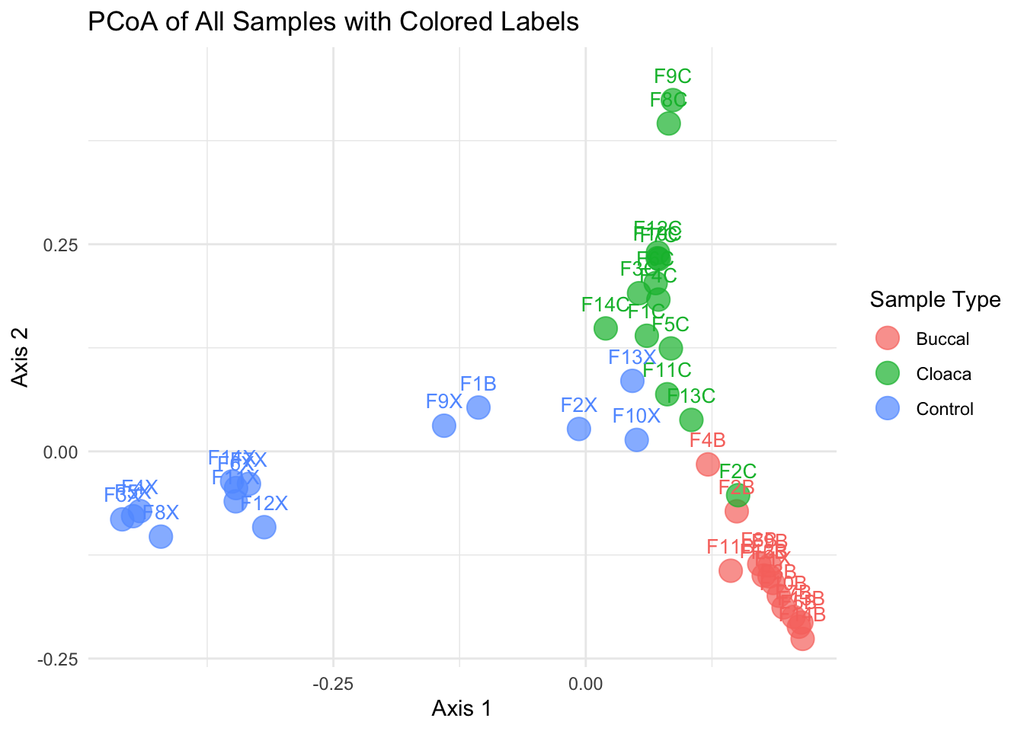

```r
# --- 1. Start with the FULL, corrected dataset ---
# This object has all 42 samples (Buccal, Cloaca, and Control).
physeq_full_dataset <- physeq_final

# --- 2. Normalize to relative abundance ---
physeq_full_rel_abund <- transform_sample_counts(physeq_full_dataset, function(x) x / sum(x))

# --- 3. Re-calculate the distance matrix on the full dataset ---
full_dist_bray <- phyloseq::distance(physeq_full_rel_abund, method = "bray")

# --- 4. Re-calculate the PCoA ordination on the full dataset ---
# This new ordination object will have 42 rows of coordinates.
pcoa_ordination_full <- ordinate(physeq_full_rel_abund, method = "PCoA", distance = full_dist_bray)

# --- 5. Create the data frame for plotting ---
# Now, both the coordinates and the metadata will have 42 rows, fixing the error.
plot_data <- data.frame(
  pcoa_ordination_full$vectors[, 1:2],
  as(sample_data(physeq_full_rel_abund), "data.frame")
)

# --- 6. Build the final plot using ggplot() ---
ggplot(plot_data, aes(x = Axis.1, y = Axis.2, color = SampleType)) +
  geom_point(size = 5, alpha = 0.7) +
  geom_text(aes(label = rownames(plot_data)), # Use row names for labels
            nudge_y = 0.03,
            size = 3.5,
            show.legend = FALSE) +
  theme_minimal() +
  labs(
    title = "PCoA of All Samples with Colored Labels",
    color = "Sample Type",
    x = "Axis 1",
    y = "Axis 2"
  )
```

```r
library(vegan) # This package is needed for the statistical test

# 1. Use the data with controls already removed
physeq_beta <- phyloseq_nocontrol

# 2. Normalize to relative abundance (important for beta diversity)
physeq_beta_rel <- transform_sample_counts(physeq_beta, function(x) x / sum(x))

# 3. Calculate Bray-Curtis distance
bray_dist <- phyloseq::distance(physeq_beta_rel, method = "bray")

# 4. Perform the statistical test (PERMANOVA)
# This is the most important step. It gives you a p-value for beta diversity.
permanova_test <- adonis2(bray_dist ~ SampleType, data = as(sample_data(physeq_beta_rel), "data.frame"))

# Print the results of the test
print(permanova_test)
```

```
## Permutation test for adonis under reduced model
## Permutation: free
## Number of permutations: 999
##
## adonis2(formula = bray_dist ~ SampleType, data = as(sample_data(physeq_beta_rel), "data.frame"))
##          Df SumOfSqs      R2     F Pr(>F)
## Model     1    1.028 0.08114 2.296  0.001 ***
## Residual 26   11.642 0.91886
## Total    27   12.670 1.00000
## ---
## Signif. codes:  0 '***' 0.001 '**' 0.01 '*' 0.05 '.' 0.1 ' ' 1
```

```
## No available covariate data to map on the points for this plot `type`
```

```
## Ignoring unknown labels:
## • colour : "Sample Type"
```

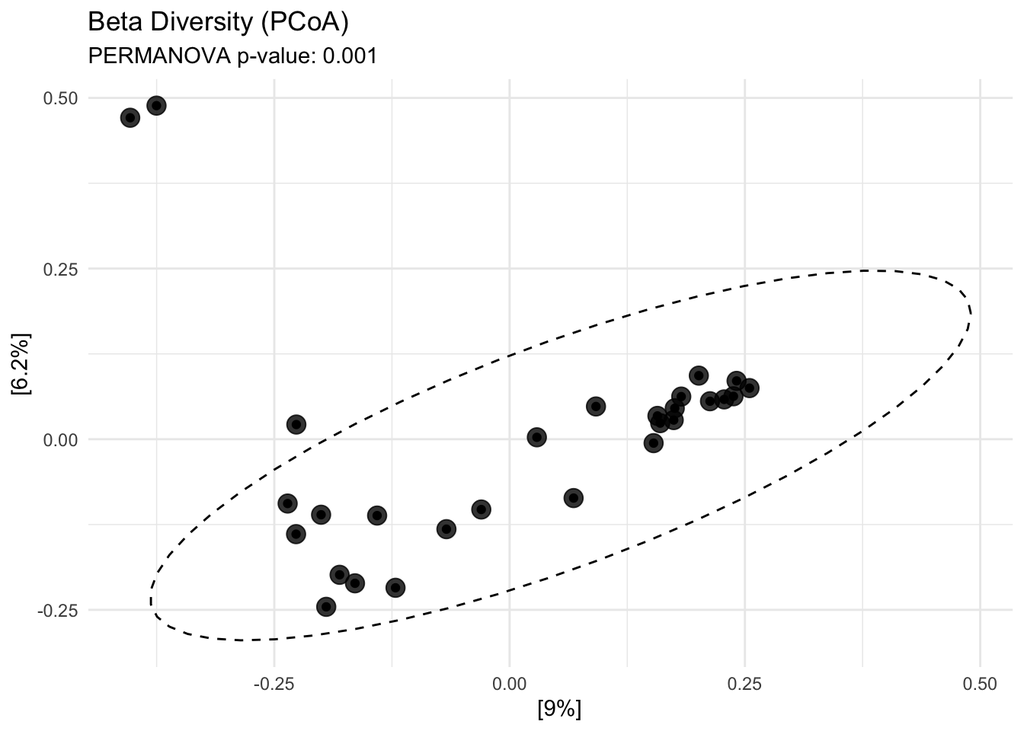

```r
# 5. Create the PCoA plot to visualize the result
pcoa_ordination <- ordinate(physeq_beta_rel, method = "PCoA", distance = bray_dist)

plot_ordination(physeq_beta_rel, pcoa_ordination, color = "SampleType") +
  geom_point(size = 4, alpha = 0.8) +
  stat_ellipse(type = "t", linetype = 2) + # Adds circles around the groups
  theme_minimal() +
  labs(
    title = "Beta Diversity (PCoA)",
    subtitle = paste("PERMANOVA p-value:", round(permanova_test$`Pr(>F)`[1], 4)),
    color = "Sample Type"
  )
```

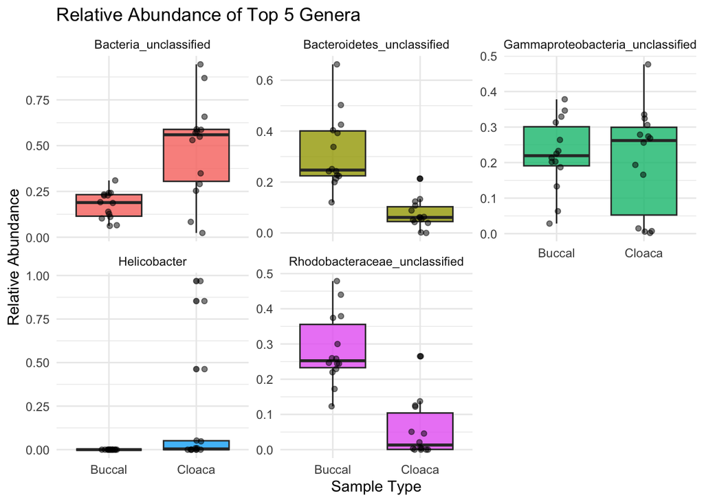

```r
# 1. Agglomerate to the "Genus" level
genus_abund <- tax_glom(phyloseq_nocontrol, taxrank = "Genus", NArm = FALSE)

# 2. Find the names of the top 5 most abundant genera
top5_genera_names <- names(sort(taxa_sums(genus_abund), decreasing = TRUE)[1:5])

# 3. Subset your phyloseq object to only these top 5
physeq_top5 <- prune_taxa(top5_genera_names, genus_abund)

# 4. Convert to relative abundance for plotting
physeq_top5_rel <- transform_sample_counts(physeq_top5, function(x) x / sum(x))

# 5. Create the boxplots
library(ggplot2)
ggplot(psmelt(physeq_top5_rel), aes(x = SampleType, y = Abundance, fill = Genus)) +
  geom_boxplot(alpha = 0.8) +
  geom_jitter(width = 0.1, alpha = 0.5) + # Add individual points
  facet_wrap(~Genus, scales = "free_y") +
  theme_minimal() +
  theme(legend.position = "none") + # Hide legend as titles are enough
  labs(
    title = "Relative Abundance of Top 5 Genera",
    x = "Sample Type",
    y = "Relative Abundance"
  )
```

```r
# First, you might need to install DESeq2. It's from Bioconductor.
# if(!requireNamespace("BiocManager", quietly = TRUE)) install.packages("BiocManager")
# BiocManager::install("DESeq2")

library(DESeq2)

# 1. Convert your phyloseq object to a DESeq2 object
#    We use 'phyloseq_nocontrol' because DESeq2 needs raw counts, not relative abundance.
#    And we'll test on the Genus level.
genus_level_data <- tax_glom(phyloseq_nocontrol, taxrank = "Genus")
deseq_obj <- phyloseq_to_deseq2(genus_level_data, ~ SampleType)
# 2. Run the DESeq analysis
#    This function runs the statistical test.
deseq_obj <- DESeq(deseq_obj)
```

```
## -- replacing outliers and refitting for 17 genes
## -- DESeq argument 'minReplicatesForReplace' = 7
## -- original counts are preserved in counts(dds)
```

```r
# 3. Get the results table
#    We specify the comparison we want: Buccal vs. Cloaca.
res <- results(deseq_obj, contrast = c("SampleType", "Buccal", "Cloaca"))

# 4. Filter for only the significant results
#    We're looking for an adjusted p-value (padj) less than 0.05.
res_significant <- subset(res, padj < 0.05)

# 5. View the results
#    This table shows you every genus that is significantly different.
print(res_significant)
```

```
## log2 fold change (MLE): SampleType Buccal vs Cloaca
## Wald test p-value: SampleType Buccal vs Cloaca
## DataFrame with 23 rows and 6 columns
##            baseMean log2FoldChange     lfcSE      stat      pvalue        padj
##           <numeric>      <numeric> <numeric> <numeric>   <numeric>   <numeric>
## Otu000003  80.04459       -1.34853  0.341637  -3.94728 7.90451e-05 6.25774e-04
## Otu000005  60.03051        2.33701  0.532536   4.38846 1.14156e-05 9.85892e-05
## Otu000009  17.47335        4.70849  0.790586   5.95569 2.58972e-09 1.23012e-07
## Otu000011  27.68316        3.16520  0.554814   5.70497 1.16363e-08 3.68483e-07
## Otu000012   4.04449        2.51834  0.446557   5.63946 1.70580e-08 4.05127e-07
## ...             ...            ...       ...       ...         ...         ...
## Otu000258  0.869737        2.68656  1.040104   2.58298 0.009795223 0.042297555
## Otu000292  2.077494        1.74745  0.684243   2.55385 0.010653920 0.044005320
## Otu000471  1.748027        2.98764  0.856181   3.48950 0.000483929 0.002704309
## Otu000560  1.016504        3.02785  0.783660   3.86373 0.000111667 0.000816028
## Otu000886  5.721324       -1.96298  0.719335  -2.72889 0.006354872 0.030185642
```

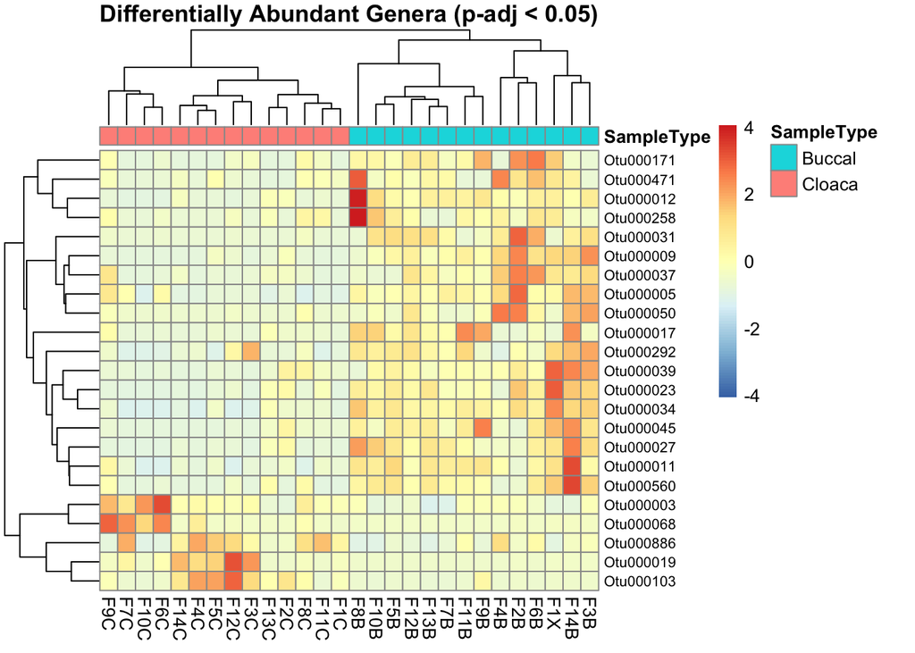

```r
# You will need the pheatmap package.
# install.packages("pheatmap")
library(pheatmap)

# 1. Get the names of your significant genera from the DESeq2 results
sig_genera_names <- rownames(res_significant)

# 2. Get the normalized abundance data from your DESeq object
# The 'rlog' transformation is ideal for heatmaps as it stabilizes variance
rld <- rlog(deseq_obj, blind = FALSE)
rld_mat <- assay(rld)

# 3. Create a final matrix for the heatmap with only the significant genera
sig_heatmap_mat <- rld_mat[sig_genera_names, ]

# 4. Get your metadata for annotation
annotation_df <- as.data.frame(colData(deseq_obj)[, "SampleType", drop = FALSE])

# 5. Create the heatmap!
pheatmap(sig_heatmap_mat,
         annotation_col = annotation_df,
         cluster_rows = TRUE,
         cluster_cols = TRUE,
         show_colnames = TRUE,
         main = "Differentially Abundant Genera (p-adj < 0.05)",
         fontsize_row = 8,
         scale = "row") # Scaling by row highlights which samples have high vs. low abundance of a given genus
```

```r
# --- Part A: Perform the Differential Abundance Analysis ---

# Ensure required packages are loaded
library(DESeq2)
library(phyloseq)
library(pheatmap)
library(ggplot2)

# 1. Start with your clean, no-controls phyloseq object
#    We will agglomerate by Genus for the test.
genus_level_data <- tax_glom(phyloseq_nocontrol, taxrank = "Genus")

# 2. Convert the phyloseq object to a DESeq2 object
#    The design formula ~ SampleType tells DESeq2 which groups to compare.
deseq_obj <- phyloseq_to_deseq2(genus_level_data, ~ SampleType)
# 3. Run the DESeq analysis to find differences
deseq_obj <- DESeq(deseq_obj)
```

```
## -- replacing outliers and refitting for 17 genes
## -- DESeq argument 'minReplicatesForReplace' = 7
## -- original counts are preserved in counts(dds)
```

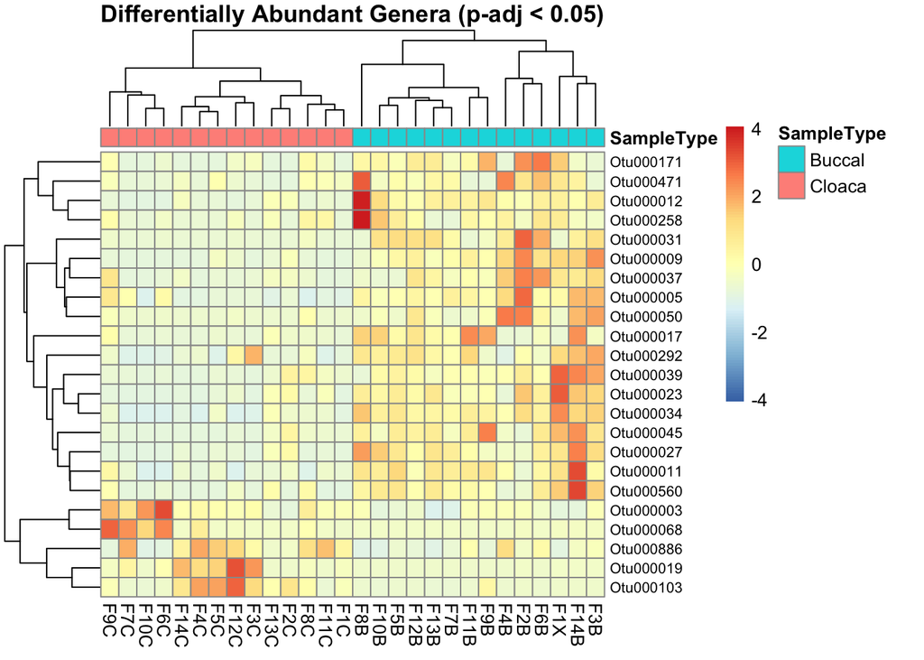

```r
# 4. Get the results table, comparing Buccal vs. Cloaca
res <- results(deseq_obj, contrast = c("SampleType", "Buccal", "Cloaca"))

# 5. Filter for the statistically significant results (adjusted p-value < 0.05)
res_significant <- subset(res, padj < 0.05)

# --- Part B: Create the Publication-Quality Heatmap ---

# 1. Get the names of the significant genera
sig_genera_names <- rownames(res_significant)

# If there are no significant genera, stop here. Otherwise, create the plot.
if (length(sig_genera_names) > 0) {

  # 2. Get normalized abundance data (rlog transformed for visualization)
  rld <- rlog(deseq_obj, blind = FALSE)
  rld_mat <- assay(rld)

  # 3. Create a matrix containing only the significant genera
  sig_heatmap_mat <- rld_mat[sig_genera_names, ]

  # 4. Get sample metadata for the annotation bar
  annotation_df <- as.data.frame(colData(deseq_obj)[, "SampleType", drop = FALSE])

  # 5. Generate the heatmap
  pheatmap(sig_heatmap_mat,
           annotation_col = annotation_df,
           cluster_rows = TRUE,
           cluster_cols = TRUE,
           show_colnames = TRUE,
           main = "Differentially Abundant Genera (p-adj < 0.05)",
           fontsize_row = 8,
           scale = "row") # Scaling by row is crucial for visualizing relative abundance patterns
} else {
  print("No statistically significant genera were found with an adjusted p-value < 0.05.")
}
```

```r
# --- Part C: Display the Results Table ---
print("--- Statistically Significant Genera ---")
```

```
## [1] "--- Statistically Significant Genera ---"
```

```r
print(res_significant)
```

```
## log2 fold change (MLE): SampleType Buccal vs Cloaca
## Wald test p-value: SampleType Buccal vs Cloaca
## DataFrame with 23 rows and 6 columns
##            baseMean log2FoldChange     lfcSE      stat      pvalue        padj
##           <numeric>      <numeric> <numeric> <numeric>   <numeric>   <numeric>
## Otu000003  80.04459       -1.34853  0.341637  -3.94728 7.90451e-05 6.25774e-04
## Otu000005  60.03051        2.33701  0.532536   4.38846 1.14156e-05 9.85892e-05
## Otu000009  17.47335        4.70849  0.790586   5.95569 2.58972e-09 1.23012e-07
## Otu000011  27.68316        3.16520  0.554814   5.70497 1.16363e-08 3.68483e-07
## Otu000012   4.04449        2.51834  0.446557   5.63946 1.70580e-08 4.05127e-07
## ...             ...            ...       ...       ...         ...         ...
## Otu000258  0.869737        2.68656  1.040104   2.58298 0.009795223 0.042297555
## Otu000292  2.077494        1.74745  0.684243   2.55385 0.010653920 0.044005320
## Otu000471  1.748027        2.98764  0.856181   3.48950 0.000483929 0.002704309
## Otu000560  1.016504        3.02785  0.783660   3.86373 0.000111667 0.000816028
## Otu000886  5.721324       -1.96298  0.719335  -2.72889 0.006354872 0.030185642
```